# Data Science Capstone Project Spring 2024 - Bayesian Linear Regression

Author

Mary Catherine Morrow

Published

February 5, 2024

## Introduction

### Article 1 from Week 2:

**Title:** Bayesian multivariate linear regression with application to change point models in hydrometeorological variables

**Summary:** The article cited first discusses the history of Bayesian analysis, including the definition, and how it relates to climate change. It then dives into three different Bayesian change point detection models (Perreault et al. [2000a], Perreault et al. [2000b], and Rasmussen [2001]) and how they compare against Bayesian analysis paired with Gibbs sampling. By comparing against these three models, the proposed method “can readily be applied to cases where the change point simultaneously occurs in several response variables, to cases where the change does not occur with certainty and to cases where informative priors are appropriate”. (O. Seidou 2007)

**Citation:** O. Seidou, J. Asselin, and T. B. M. J. Ouarda, “Bayesian multivariate linear regression with application to change point models in hydrometeorological variables,” Water Resources Research, vol. 43, no. 8, Aug. 2007, doi: 10.1029/2005wr004835.

### Article 2 from Week 2:

**Title:** Positional error compensation for aviation drilling robot based on Bayesian linear regression

**Summary:** The article cited discusses how Bayeisan Linear Regression was used to model positional accuracy of aviation drilling robots using a training data set. After the model was built, experiments were performed to confirm the model’s functionality, where a test dataset was used. The experiements showed that using this method to model the positional accuracy resulted in being within the 95% confidence interval and a high R2 value of 0.941, meaning the Bayesian Linear Regression method has good compensation performance for aviation drilling.(D. Chen and Kong 2024)

**Citation:** D. Chen, P. Lv, L. Xue, H. Xing, L. Lu, and D. Kong, “Positional error compensation for aviation drilling robot based on Bayesian linear regression,” Engineering Applications of Artificial Intelligence, vol. 127, p. 107263, Jan. 2024, doi: 10.1016/j.engappai.2023.107263.

### Article 1 from Week 3:

**Title:** Evidence for a non-universal Kennicutt-Schmidt relationship using hierarchical Bayesian linear Regression

**Summary:** The goal of the research described in the article cited was to create a model, particularly a Bayesian Linear Regression (BLR) model, that estimated the parameters of the Kennicutt-Schmidt (KS) law and the hierarchal structure of a given data set. The BLR model was constructed using Markov Chain Monte Carlo (MCMC) and Gibb’s sampling. The model was tested with synthetic test data sets made to match the format of the model building data set. The model was considered to have a high degree of accuracy by comparing median of the posterior, the posterior distributions of the slope and intercept, the median of the scatter term, and PDFs of the estimated group parameters against the true values. Then, the Bayesian model was compared to the Ordinary Least Squares (OLS) model for an accuracy check. Here, the OLS model consistently overestimated the slopes and underestimated the intercepts for individual galaxies within the group as well as the group as a whole. This was expected as the data set included noise and scatter, which are not accounted for in the OLS method. By testing distribution hypotheses using the OLS method and comparing it against the Bayesian method, it was shown that Bayesian posterior can recover individuals’ slopes and intercepts regardless if the assumed distribution is incorrect. However, accuracy of the Bayesian method increases if the correct distribution assumptions are made. (R. Shetty and Bigiel 2013)

**Citation:** R. Shetty, B. C. Kelly, and F. Bigiel, “Evidence for a non-universal Kennicutt–Schmidt relationship using hierarchical Bayesian linear regression,” Monthly Notices of the Royal Astronomical Society, vol. 430, no. 1, pp. 288–304, Jan. 2013, doi: 10.1093/mnras/sts617.

### Article 2 from Week 3:

**Title:** Bayesian linear regression with sparse priors

**Summary:** This cited article details the Bayesian method for high-dimensional linear regression under sparsity constraints. A standard model was used, but it focused mainly on the sparse setup, where n is less than or greater than p and many of the coefficients of the parameter vector are zero, or close there to. Within the work, it is shown that the LASSO frequentist method is non-Bayesian. (I. Castillo and Vaart 2015)

**Citation:** I. Castillo, J. Schmidt-Hieber, and A. Van Der Vaart, “Bayesian linear regression with sparse priors,” The Annals of Statistics, vol. 43, no. 5, Oct. 2015, doi: 10.1214/15-aos1334.

### Article 1 from Week 4:

**Title:** How to lose at Monte Carlo: a simple dynamical system whose typical statistical behavior is non-computable

**Summary:** This cited article expands upon the idea of using statistical predictions, with the Monte Carlo method , to make “future behavior of nonlinear dynamical systems”, and aimed to find where the Monte Carlo method fails. This is important because it helps further define the limitations of the method, which allows for more proper use of the method in the future. Through the analysis, the Monte Carlo method was deemed to not work through the use of non-computable physical measures, like a black-box. (C. Rojas 2020)

**Citation:** C. Rojas and M. Yampolsky, “How to lose at Monte Carlo: a simple dynamical system whose typical statistical behavior is non-computable,”Proceedings of the 52nd Annual ACM SIGACT Symposium on Theory of Computing, pp. 1066–1072, Jun. 2020, doi: 10.1145/3357713.3384237.

### Article 2 from Week 4:

**Title:** Gibbs sampling on large lattice with GMRF

**Summary:** The goal of the cited article was to construct a method for using Gibbs sampling for large lattices, which includes greater than 100 points. This is helpful as it allows for Gibbs sampling to be applied to 2D and 3D lattice structures using GMRF (Gaussian Markov Random Fields) covariance. This article gives good applications of GMRF, Gibbs sampling, and Gibbs sampling with GMRF.(D. Marcotte 2018)

**Citation:** D. Marcotte and D. Allard, “Gibbs sampling on large lattice with GMRF,” Computers & Geosciences, vol. 111, Art. no. 190, Feb. 2018, doi: 10.1016/j.cageo.2017.11.012.

## Analysis and Results

### Data and Visualization

```r
# loading packages
library(tidyverse)
library(knitr)
library(ggthemes)
library(ggrepel)
library(dslabs)
```

```r
# Load Data
kable(head(murders))
```

| state | abb | region | population | total |
| --- | --- | --- | --- | --- |
| Alabama | AL | South | 4779736 | 135 |
| Alaska | AK | West | 710231 | 19 |
| Arizona | AZ | West | 6392017 | 232 |
| Arkansas | AR | South | 2915918 | 93 |
| California | CA | West | 37253956 | 1257 |
| Colorado | CO | West | 5029196 | 65 |

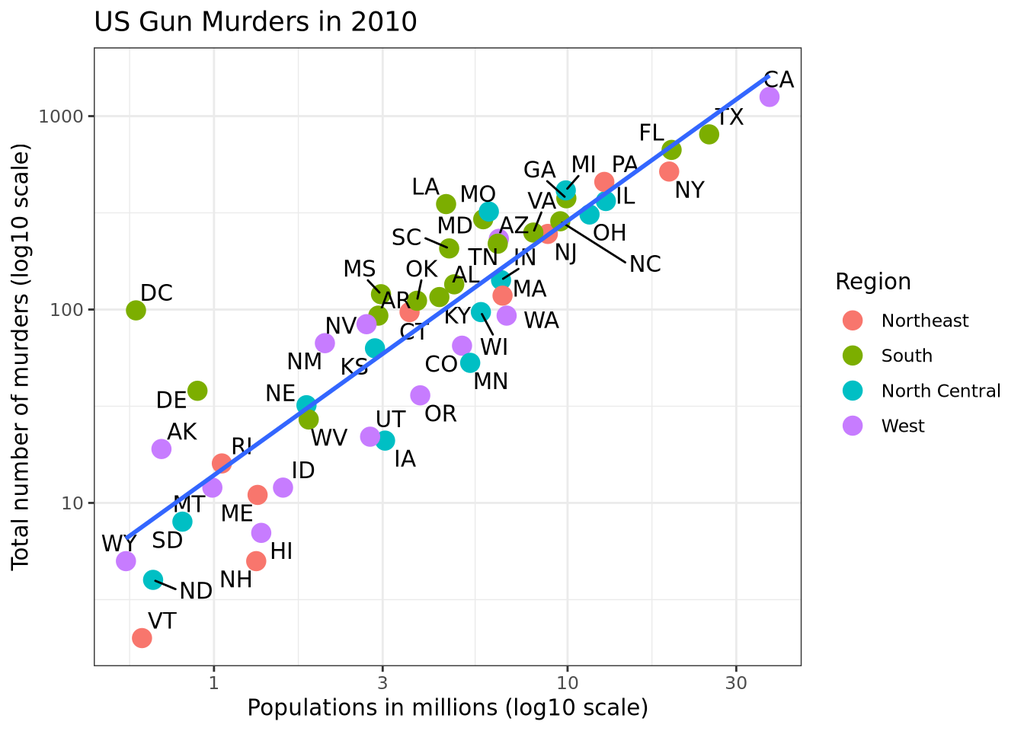

```r
ggplot1 = murders %>% ggplot(mapping = aes(x=population/10^6, y=total))

  ggplot1 + geom_point(aes(col=region), size = 4) +
  geom_text_repel(aes(label=abb)) +
  scale_x_log10() +
  scale_y_log10() +
  geom_smooth(formula = "y~x", method=lm,se = F)+
  xlab("Populations in millions (log10 scale)") +
  ylab("Total number of murders (log10 scale)") +
  ggtitle("US Gun Murders in 2010") +
  scale_color_discrete(name = "Region")+
      theme_bw()
```

## References

C. Rojas, M. Yampolsky. 2020. “How to Lose at Monte Carlo: A Simple Dynamical System Whose Typical Statistical Behavior Is Non-Computable.” *Proceedings of the 52nd Annual ACM SIGACT Symposium on Theory of Computing*, p.1066–1072.

D. Chen, L. Xue, P. Lv, and D. Kong. 2024. “Positional Error Compensation for Aviation Drilling Robot Based on Bayesian Linear Regression.” *Engineering Applications of Artificial Intelligence* vol. 127: p.107263.

D. Marcotte, D. Allard. 2018. “Gibbs Sampling on Large Lattice with GMRF.” *Computers & Geosciences* Vol. 111, Art. no. 190.

I. Castillo, J. Schmidt-Hieber, and A. Van Der Vaart. 2015. “Bayesian Linear Regression with Sparse Priors.” *The Annals of Statistics* vol. 43 no. 5.

O. Seidou, T. B. M. J. Ouarda, J. Asselin. 2007. “Bayesian Multivariate Linear Regression with Application to Change Point Models in Hydrometeorological Variables.” *Water Resources Research* vol.43 no.8.

R. Shetty, B. C. Kelly, and F. Bigiel. 2013. “Evidence for a Non-Universal Kennicutt–Schmidt Relationship Using Hierarchical Bayesian Linear Regression.” *Monthly Notices of the Royal Astronomical Society* vol. 430 no. 1: p.288–304.